# The effect of COVID-19 pandemic on Croatian tourist sector

Bogdan, S., Sikic, L. and Suzana, Baresa

01 srpanj, 2021

## ABSTRACT

This paper analyses the effect of the COVID-19 pandemic spread the into Europe on the tourist stocks in Croatia by application of the event study methodology. The analysis starts with the descriptive overview of market wide performance of different sectors in the period before, during and after the initial pandemic outbreak and afterwards explicitly tests for the COVID-19 outbreak effects on the tourist sector. First, the 35 day long event window is specified so that important events related to the pandemic can be identified. Second, the first officially reported COVID-19 incidence in Italy and World Health Organization declaration of global pandemic are used as identified events in a shorter 10 day window event study estimation. The results point to the significant negative and robust effect of COVID-19 pandemic on the returns of tourist stocks in the Zagreb stock exchange. However, the overall results do not provide evidence of the relatively stronger COVID-19 effects on tourist sector but rather equal effects across different sectors.

# INTRODUCTION

The coronavirus pandemic spread around the globe in just a few months after the first case was registered, leaving huge consequences in the form of threatening the health and human lives, great economic losses, and psychological fear. The presence of the virus has prevented potential tourists from feeling safe in the tourist destinations and produced a complete stall in the functioning of tourism business. According to the UNWTO (2021), international tourist arrivals (overnight visitors) dropped by 74% in 2020 compared to the 2019, due to the massive drop in tourist demand and travel restrictions. The pandemic produced a loss of USD 1.3 trillion in export revenues which is eleven times greater loss compared to the global financial crisis from 2008. UNWTO forecasted that it could pass between 2.5 or even 4 years for international tourism to return on the old track from 2019. The effectiveness of vaccines and the level of vaccination of the population will certainly play an important role and are expected to reduce the number of new cases, as well as to the mitigation of travel restriction measures and the restoration of consumer confidence. The consequences of the pandemic are especially pronounced in the tourism dependent countries like Croatia.

According to the UNWTO (2021), Croatia is among the 10 most vulnerable countries according to the criterion of the direct impact of tourism on the share of GDP. More precisely, in the first place is Macao (China) 48%, followed by: Fiji 13%, Jordan 12%, Spain 12% and Croatia with 11%. Many countries have introduced travel restrictions and knowing that the share of foreign tourists in Croatia is 89% (UNWTO, 2021), negative financial results are expected from companies that are directly or indirectly involved in tourism. Beside aforementioned facts, tourism is a significant contributor to national exports (35%) (UNWTO, 2021) and this contraction will have negative macroeconomic consequences. Although Croatia achieved a record high in 2019 in terms of the total number of arrivals and overnight stays of domestic and foreign tourists in 2020, due to the global corona pandemic, there was a steep decline compared to 2019. The pronounced drop in the tourism spilled over into the capital market and caused turmoil, so the purpose of this research is to investigate how tourism stock prices responded to the outbreak of the COVID-19 pandemic by using event study methodology. This methodology has proven to be especially useful in identifying the effect of a particular event on stock market returns.

This study contributes to the literature by analyzing the impact of global COVID-19 pandemic on tourism sector in Croatia. As a practical implication, this study will be particularly useful to current and potential investors as well as policy management during this and other future unexpected crises. The remainder of this study is structured as follows: the section 2 performs an overview of Croatian tourism before and during the Covid-19 pandemic, the section 3 outlines a detailed literature review, the section 4 presents data and methodology, the section 5 reports the results of empirical research and discussion and finally in the last section a conclusion, limitations and future research recommendations are summarized.

# TOURISM IN CROATIA BEFORE AND DURING THE COVID-19 PANDEMIC

# LITERATURE REVIEW

Event study methodology is used in a variety of application settings with the aim of measuring the impact of unforeseen or unanticipated events on prices or business performance. This methodology is has therefore found wide usage in the field of finance for measuring corporate announcements on financial performance, investor behavior or similar. The implicit assumption for the application of event study methodology is that markets are efficient, i.e. publicly available information are reflected in the prices of securities, so it was used in economics for testing the market efficiency on the capital market (Kothari and Warner (2007)). However, Novak (2019) rejected the weak-form efficiency hypothesis on Croatian capital market. One of the first authors which showed the usefulness of the event study methodology were Ball and Brown (1968) who researched the impact of earnings surprises on stock prices. Brown and Warner (1980) have compared different event study methodologies and concluded that complicated methodologies will not benefit with better results in comparison with a simple one factor market model. Asquith and W (1983) concluded that initiating a dividend policy as an information has a strong and positive impact on the market reaction. Miletic (2011) analyzed impact of dividend announcement on Croatian capital market by event study methodology. Results confirmed that increase or decrease of dividend significantly affect stock price in the same direction while dividend retention had no affect on stock price. Abarbanell and Park (2017) found that companies with larger ex ante earnings response coefficients are linked to a greater propensity to positively bias earnings surprise and more negative intercepts in regressions of announcements returns on earnings surprises. Skrinjaric and Orlović (2019) applied event study methodology in order to test whether political events regarding the concern Agrokor affect stock prices. Their results indicate that stocks which belong to Agrokor concern suffered from lowering returns while other liquid stocks on the Zagreb stock exchange were not affected.

Kothari, S., and Jerold B. Warner. 2007. “Econometrics of Event Studies.” In.

Novak, I. 2019. “EFFICIENT Market Hypothesis: CASE of the Croatian Capital Market.” In.

Ball, Ray, and P Brown. 1968. “EMPIRICAL Evaluation of Accounting Income Numbers.” *Journal of Accounting Research* 6 (2): 159–78. https://EconPapers.repec.org/RePEc:bla:joares:v:6:y:1968:i:2:p:159-178.

Brown, Stephen, and Jerold B. Warner. 1980. “Measuring Security Price Performance.” *Journal of Financial Economics* 8 (3): 205–58. https://EconPapers.repec.org/RePEc:eee:jfinec:v:8:y:1980:i:3:p:205-258.

Asquith, Paul, and Mullins W. 1983. “The Impact of Initiating Dividend Payments on Shareholders’ Wealth.” *The Journal of Business* 56 (1): 77–96. https://EconPapers.repec.org/RePEc:ucp:jnlbus:v:56:y:1983:i:1:p:77-96.

Miletic, M. 2011. “Stock Price Reaction to Dividend Announcement in Croatia.” *Economic Research-Ekonomska Istraivanja* 24: 147–56.

Abarbanell, Jeffery, and Hyungshin Park. 2017. “Do Bright-Line Earnings Surprises Really Affect Stock Price Reactions?” *Manag. Sci.* 63 (4): 1063–84. https://doi.org/10.1287/mnsc.2015.2376.

Skrinjaric, Tihana, and Zrinka Orlović. 2019. “Effects of Economic and Political Events on Stock Returns: Event Study of the Agrokor Case in Croatia.” *Croatian Economic Survey* 21: 47–86.

Chia, Ricky Chee-Jiun, Venus Liew, and Racquel Rowland. 2020. “Daily New Covid-19 Cases, the Movement Control Order, and Malaysian Stock Market Returns.” MPRA Paper. University Library of Munich, Germany. https://EconPapers.repec.org/RePEc:pra:mprapa:107988.

Mazur, M., M. Dang, and M. Vega. 2020. “COVID-19 and the March 2020 Stock Market Crash. Evidence from S&P1500.” *Finance Research Letters* 38: 101690–0.

Wagner, A. 2020. “What the Stock Market Tells Us About the Post-Covid-19 World.” *Nature Human Behaviour*, 1–1.

Phan, D. H. B., and P. Narayan. 2020. “Country Responses and the Reaction of the Stock Market to Covid-19—a Preliminary Exposition.” *Emerging Markets Finance and Trade* 56: 2138–50.

Narayan, P., Neluka Devpura, and Hua Wang. 2020. “Japanese Currency and Stock Market—What Happened During the Covid-19 Pandemic?☆.” *Economic Analysis and Policy* 68: 191–98.

Contessi, Silvio, and Pierangelo De Pace. 2020. “The International Spread of Covid-19 Stock Market Collapses.” Economics Department, Working Paper Series. Economics Department, Pomona College. https://EconPapers.repec.org/RePEc:clm:pomwps:1013.

Erdem, Orhan. 2020. “Freedom and Stock Market Performance During Covid-19 Outbreak.” *Finance Research Letters* 36 (C): S1544612320306735. https://EconPapers.repec.org/RePEc:eee:finlet:v:36:y:2020:i:c:s1544612320306735.

Onali, Enrico. 2020. “COVID-19 and Stock Market Volatility.” *Capital Markets: Asset Pricing & Valuation eJournal*.

Rahman, Lutfur, Abu S. Amin, and M. Mamun. 2020. “The Covid – 19 Outbreak and Stock Market Reactions: Evidence from Australia.” *Finance Research Letters*, 101832.

Harjoto, Maretno Agus, Fabrizio Rossi, and John K. Paglia. 2021. “COVID-19: Stock Market Reactions to the Shock and the Stimulus.” *Applied Economics Letters* 28 (10): 795–801. https://doi.org/10.1080/13504851.2020.1781767.

Okorie, David Iheke, and Boqiang Lin. 2020. “Stock Markets and the Covid-19 Fractal Contagion Effects.” *Finance Research Letters* 38: 101640–0.

Panyagometh, Kamphol. 2020. “The Effects of Pandemic Event on the Stock Exchange of Thailand.” *Economies* 8 (4): 1–22. https://ideas.repec.org/a/gam/jecomi/v8y2020i4p90-d433708.html.

He, Pinglin, Yulong Sun, Ying Zhang, and Tao Li. 2020. “COVID–19’s Impact on Stock Prices Across Different Sectors—An Event Study Based on the Chinese Stock Market.” *Emerging Markets Finance and Trade* 56 (10): 2198–2212. https://doi.org/10.1080/1540496X.2020.178.

Liu, Haiyue, Aqsa Manzoor, C. Wang, L. Zhang, and Zaira Manzoor. 2020. “The Covid-19 Outbreak and Affected Countries Stock Markets Response.” *International Journal of Environmental Research and Public Health* 17.

Kandil Göker, İlkut Elif, Binali Selman Eren, and Süleyman Serdar Karaca. 2020. “The Impact of the Covid-19 (Coronavirus) on the Borsa Istanbul Sector Index Returns: An Event Study.” *Gaziantep University Journal of Social Sciences*. Gaziantep Üniversitesi Yerleşkesi Şehitkamil-Gaziantep: Gaziantep University. https://doi.org/10.21547/jss.731980.

# METHODOLOGY

## DATA

This analysis uses data sample of 23 traded tourist firms retrieved from the Zagreb stock exchange (ZSE) in the period between the first trading day in 2019. and April 13th 2021. Due to the low liquidity, i.e. infrequent trading and low turnover, the initial sample is reduced to the final empirical sample of 12 firms according to the criteria of minimum of 100 trading days over the sampled period. For these 12 firms, the daily closing stock prices are used in order to calculate daily percentage returns. Since COVID-19 pandemic was gaining worldwide momentum prior to spreading into the Europe, we divide the time period into three parts: pre epidemic part ranging from the first trading day in 2019. until one week before the first reported case in Italy (Feb, 21th 2020.), ongoing pandemic from the first officially reported COVID-19 incidence in Italy until one week after the lockdown was introduced in Croatia (March,19th 2020.) and post event period from March, 26th 2020 until the end of the sample period (April, 13th,2021). The reason to specify the event period loosely, i.e. one week before first COVID-19 incidence in Italy and one week after the lockdown in Croatia, is to allow uncertainty and new information set to become incorporated in the market valuations due to the novelty of the pandemic event and media reporting vs. policy reaction lag related to the pandemic outbreak.

Table 1: Table 1: Overview of the market returns over the analysed period

| Pandemic | Index | Total | Average | Stdev | Min | Max |
| --- | --- | --- | --- | --- | --- | --- |
| Ongoing | CrobexInd | -24.359 | -0.609 | 4.116 | -14.690 | 7.481 |
| Ongoing | CrobexKonstr | -16.624 | -0.416 | 4.652 | -15.300 | 10.850 |
| Ongoing | CrobexNutr | -26.150 | -0.654 | 3.719 | -12.460 | 6.432 |
| Ongoing | CrobexTr | -25.882 | -0.647 | 3.363 | -11.313 | 5.460 |
| Ongoing | CrobexTur | -25.204 | -0.630 | 3.361 | -10.975 | 6.572 |
| Post | CrobexInd | 40.059 | 0.159 | 1.282 | -3.772 | 8.295 |
| Post | CrobexKonstr | 77.072 | 0.306 | 2.340 | -6.538 | 8.203 |
| Post | CrobexNutr | 9.040 | 0.036 | 1.423 | -11.098 | 6.014 |
| Post | CrobexTr | 17.694 | 0.070 | 0.631 | -1.821 | 2.998 |
| Post | CrobexTur | 22.590 | 0.090 | 1.150 | -3.223 | 5.170 |
| Pre | CrobexInd | -1.412 | -0.005 | 1.256 | -4.032 | 6.658 |
| Pre | CrobexKonstr | -31.339 | -0.114 | 2.261 | -8.131 | 6.921 |
| Pre | CrobexNutr | 42.658 | 0.156 | 1.763 | -10.661 | 8.707 |
| Pre | CrobexTr | 19.076 | 0.070 | 0.418 | -1.609 | 2.053 |
| Pre | CrobexTur | -0.430 | -0.002 | 0.623 | -2.004 | 2.868 |

## EVENT STUDY MEDHODOLOGY

Fama, et al, Eugene F. 1969. “The Adjustment of Stock Prices to New Information.” *International Economic Review* 10 (1): 1–21. https://EconPapers.repec.org/RePEc:ier:iecrev:v:10:y:1969:i:1:p:1-21.

Stock market returns are estimated in the pre-event time period, according to the formula:

$R_{it}=\frac{P_{i,t}-P_{i,t-1}}{P_{i,t-1}}$

where $P_{it}$ is the price of the stock *i* in the period *t*. The abnormal return $AR_{it}$ is defined as a difference between the actual and expected return $E[R_{it}|I_{t}]$ during the event window:

$AR_{it} = R_{it}-E[R_{it}|I_{t}]$.

The expected returns during the event window are parametrized according to the OLS specification:

$E[R_{it}|I_{t}] =\alpha_{it}+\beta_{it}R_{MKT_{it}} + \epsilon_{it}$

where $R_{MKT_{it}}$ represents the return model of choice such as market model, capital asset pricing model(Mossin (1966)), Fama-French factor model(Fama and French (1992)) and Carhart four factor model(Carhart (1997)). In this analysis, the market model is applied. The abnormal return $AR_{it}$ is defined as a difference between the actual and expected return during the event window:

Mossin, J. 1966. “Equilibrium in a Capital Asset Market.” *Econometrica* 34 (4): 768–83.

Fama, Eugene, and Kenneth French. 1992. “The Cross-Section of Expected Stock Returns.” *Journal of Finance* 47 (2): 427–65. https://EconPapers.repec.org/RePEc:bla:jfinan:v:47:y:1992:i:2:p:427-65.

Carhart, Mark. 1997. “On Persistence in Mutual Fund Performance.” *Journal of Finance* 52 (1): 57–82. https://EconPapers.repec.org/RePEc:bla:jfinan:v:52:y:1997:i:1:p:57-82.

$AR_{it} = R_{it}-E[R_{it}|I_{t}]$

or differently:

$AR_{it} = R_{it}-(\alpha_{it}+\beta_{it}R_{MKT_{it}})$

where $\alpha_{it}$ and $\beta_{it}$ represent estimated parameters from the ordinary least squares model.

Systematic deviations of $AR_{it}$ from 0 implies that the market mispricing of the event and offers a profitable arbitrage strategy. The cumulative abnormal return $CAR$ is computed by aggregating abnormal returns:

$CAR_{(t1,t2)}=\sum_{t=t_{1}}^{t_{2}}AR_{t}$.

The null hypothesis of a zero cumulative abnormal return ($H_{0}:CAR_{it}=0$) is tested against the alternative of a nonzero CAR $H_{0}:CAR_{it}\neq0$ by *t* statistic obtained with the following procedure:

$s_{AR_{i}}^{2}= \frac{1}{M_{i}-2}\sum_{t=t_{0}}^{t_{1}}e_{it}^{2}$

$s_{CAR_{i}}^{2}= Ls_{AR_{i}}^{2}$

$t(CAR)=\frac{CAR_{i}}{s_{CAR}}$

where M is the length of the estimation window and L is the length of the respective event window. The analysis applies several parametric and nonparametric tests.

First, the battery of parametric tests is applied. The standard Brown and Warner (1985) “BW85” procedure that tests the hypothesis of the theoretical cross-sectional expected value being equal to zero. The test does not require cross-sectional independence and produces robust results even if event window and estimation period are simultaneous. However, it is not robust to part of the variance induced by the event. Boehmer, Masumeci, and Poulsen (1991) cross-sectional “t-stat” test that assumes independence of tested series and examines weather the cross-sectional expected value equals to zero. The test is robust to the event induced variance. The standardized-residuals “pt” test from Patell (1976) that examines the hypothesis of expected theoretical cross-sectional value for a given day being equal to zero. The standardization of residuals balances out the effect of event related variance, especially when compared to Brown and Warner variants. Because of the variance standardization, the “pt” test is appropriate under the presence of a highly volatile series that would potentially influence the whole sample. The test runs under the assumption of a cross-sectional independence and allows for the overlapping of event window and estimation period but is not robust to an event induced variance. The hybrid standardized cross section test from Boehmer, Masumeci, and Poulsen (1991) that combines t-test and standardized results as previously described in Pattel`s procedure. The test has a null hypothesis of cross-sectional expected value being zero and runs under the assumption of cross sectional independence. The procedure is robust to the simultaneity of event window and estimation period. Finally, the test described in Lamb (1995) that tests the hypothesis of CAR statistic being different from zero and having the advantage of being robust to the correlation in the cross-section returns.

Brown, Stephen, and Jerold B. 1985. “Using Daily Stock Returns: The Case of Event Studies.” *Journal of Financial Economics* 14 (1): 3–31. https://EconPapers.repec.org/RePEc:eee:jfinec:v:14:y:1985:i:1:p:3-31.

Boehmer, Ekkehart, Jim Masumeci, and Annette B. Poulsen. 1991. “Event-Study Methodology Under Conditions of Event-Induced Variance.” *Journal of Financial Economics* 30 (2): 253–72. https://EconPapers.repec.org/RePEc:eee:jfinec:v:30:y:1991:i:2:p:253-272.

Patell, Jm. 1976. “CORPORATE Forecasts of Earnings Per Share and Stock-Price Behavior - Empirical Tests.” *Journal of Accounting Research* 14 (2): 246–76. https://EconPapers.repec.org/RePEc:bla:joares:v:14:y:1976:i:2:p:246-276.

Boehmer, Ekkehart, Jim Masumeci, and Annette B. Poulsen. 1991. “Event-Study Methodology Under Conditions of Event-Induced Variance.” *Journal of Financial Economics* 30 (2): 253–72. https://EconPapers.repec.org/RePEc:eee:jfinec:v:30:y:1991:i:2:p:253-272.

Lamb, Reinhold P. 1995. “An Exposure-Based Analysis of Property-Liability Insurer Stock Values Around Hurricane Andrew.” *Journal of Risk and Insurance* 62: 111.

Second, to control for the robustness, several nonparametric tests are applied. The simple binomial sign test “SIGN” that indicates weather the cross-sectional frequency of abnormal returns differs from 0.5 as described in Boehmer, Masumeci, and Poulsen (1991). The test has good properties in the presence of outliers i.e. series with extreme abnormal returns, and non-symmetric cross sectional returns but is not robust in when the estimation period and the event period overlap. The binomial test “GSIGN” that indicates if the cross-sectional frequency of positive abnormal returns differs from the expected value. The test is also robust to outliers, non-symmetric abnormal returns but doesn’t allow for the overlapping periods. The difference relative to the “SIGN” test is that “GSIGN” procedure estimates the expected frequency rather than using assumed value of 0.5. Corrado and Zivney (1992) “CSIGN” procedure that uses rank ordering and exhibits robustness in the case of non-symmetric abnormal returns as well as variance jumps during the event window. The rank “RANK” procedure that orders abnormal returns according to the corresponding ranks. This procedure is robust to the non-symmetric abnormal returns and variance jumps but isn’t suitable for the event and estimation period overlapping. The modified rank “MRANK” procedure that extends regular rank test in terms of improved ordering procedure but exhibits very similar properties. Finally, the Willcoxon test “WLCX” based on the sum of ranks statistic that correspond to the ranking of non-zero differences of cross-sectional abnormal returns is used. The test is robust to overlapping of estimation and event windows.

Boehmer, Ekkehart, Jim Masumeci, and Annette B. Poulsen. 1991. “Event-Study Methodology Under Conditions of Event-Induced Variance.” *Journal of Financial Economics* 30 (2): 253–72. https://EconPapers.repec.org/RePEc:eee:jfinec:v:30:y:1991:i:2:p:253-272.

Corrado, Charles, and Terry L. Zivney. 1992. “The Specification and Power of the Sign Test in Event Study Hypothesis Tests Using Daily Stock Returns.” *Journal of Financial and Quantitative Analysis* 27 (3): 465–78. https://EconPapers.repec.org/RePEc:cup:jfinqa:v:27:y:1992:i:03:p:465-478_00.

# RESULTS AND DISCUSSION

Table 2: Table 2: The event study reuslts for the parametric tests

Date

BW80

sig

BW85

sig

t-stat

sig

pt

sig

BH

sig

LMB

sig

2020-02-17

0.155

0.154

0.500

0.938

0.899

0.154

2020-02-18

0.552

0.548

1.100

1.799

1.642

0.547

2020-02-19

-0.730

-0.725

-1.806

-2.519

-1.536

-0.724

2020-02-20

0.259

0.257

1.312

1.052

1.345

0.256

2020-02-21

0.869

0.863

0.868

1.248

1.166

0.862

2020-02-24

-4.217

***

-4.187

***

-2.027

-11.658

***

-2.235

-3.407

***

2020-02-25

-2.819

***

-2.799

***

-1.751

-4.203

***

-1.632

-2.739

***

2020-02-26

-0.482

-0.479

-0.527

-0.120

-0.072

-0.471

2020-02-27

-0.187

-0.186

-0.259

0.408

0.191

-0.184

2020-02-28

-0.659

-0.654

-0.759

-1.527

-0.875

-0.628

2020-03-02

1.810

1.797

1.335

3.738

***

1.835

1.792

2020-03-03

0.258

0.256

0.267

0.089

0.062

0.255

2020-03-04

-0.376

-0.374

-0.268

0.230

0.117

-0.373

2020-03-05

-0.554

-0.550

-0.646

-2.726

***

-1.337

-0.547

2020-03-06

-1.390

-1.380

-1.053

-5.260

***

-1.565

-1.314

2020-03-09

-5.554

***

-5.515

***

-1.900

-8.950

***

-2.210

-3.254

***

2020-03-10

-0.117

-0.116

-0.076

-2.800

***

-1.078

-0.115

2020-03-11

-4.943

***

-4.908

***

-2.259

-7.922

***

-2.397

-4.122

***

2020-03-12

-2.011

-1.997

-0.633

-5.292

***

-1.338

-1.103

2020-03-13

0.607

0.603

0.335

2.030

0.691

0.475

2020-03-16

-2.549

-2.531

-0.945

-7.119

***

-1.648

-1.761

2020-03-17

-2.212

-2.196

-1.693

-2.267

-0.638

-2.118

2020-03-18

-1.314

-1.304

-0.734

-4.098

***

-0.984

-1.183

2020-03-19

-0.440

-0.437

-0.241

0.248

0.060

-0.431

2020-03-20

-1.086

-1.078

-1.051

-2.758

***

-1.096

-1.022

2020-03-23

-0.901

-0.895

-0.559

-3.662

***

-1.064

-0.819

Table 3: Table 2: The event study reuslts for the nonparametric tests

Date

SIGN

sig

GSIGN

sig

CSIGN

sig

RANK

sig

MRANK

sig

WLCX

sig

2020-02-17

0.000

0.823

1.103

1.017

1.017

40

2020-02-18

-0.577

0.229

-0.276

0.696

0.696

43

2020-02-19

-0.577

0.229

0.827

-0.226

-0.226

20

2020-02-20

1.155

2.009

1.378

1.755

1.755

55

2020-02-21

-1.155

-0.364

0.689

0.557

0.557

26

2020-02-24

-0.577

0.229

-0.276

-0.711

-0.711

19

2020-02-25

0.000

0.823

0.000

-0.191

-0.191

27

2020-02-26

-0.577

0.229

-0.276

-0.497

-0.497

33

2020-02-27

0.000

0.823

0.551

0.832

0.832

41

2020-02-28

0.577

1.416

0.551

0.892

0.892

38

2020-03-02

0.577

1.416

1.103

1.654

1.654

55

2020-03-03

-0.577

0.229

-0.276

-0.148

-0.148

34

2020-03-04

0.000

0.823

0.827

0.269

0.269

38

2020-03-05

-0.577

0.229

0.276

0.314

0.314

29

2020-03-06

0.000

0.823

0.276

0.358

0.358

31

2020-03-09

-0.577

0.229

-0.276

-0.653

-0.653

15

2020-03-10

-1.155

-0.364

-0.551

-1.050

-1.050

27

2020-03-11

-2.309

-1.551

-1.103

-2.225

-2.225

14

2020-03-12

0.000

0.823

0.276

0.284

0.284

37

2020-03-13

-0.577

0.229

-0.276

-0.528

-0.528

35

2020-03-16

0.000

0.823

0.000

0.033

0.033

34

2020-03-17

-2.309

-1.551

-1.103

-2.036

-2.036

13

2020-03-18

1.155

2.009

0.551

0.959

0.959

43

2020-03-19

0.577

1.416

0.827

1.288

1.288

50

2020-03-20

-1.732

-0.958

-0.827

-1.526

-1.526

22

2020-03-23

0.577

1.416

0.276

0.396

0.396

34

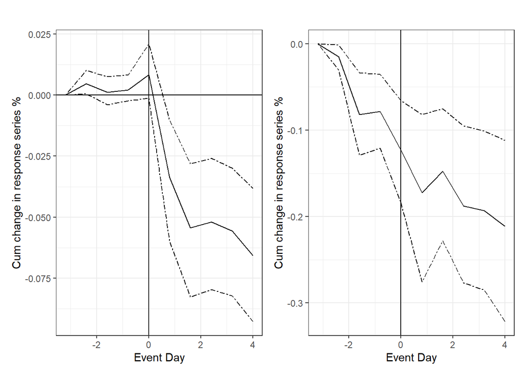

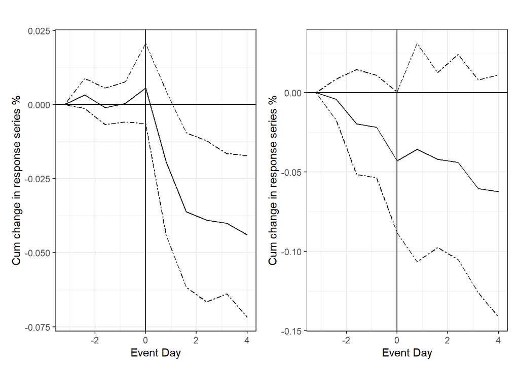

# CONCLUSION